# Project of Data 583 Advanced Predictive Modelling

Bruno Santos, Harry Sun, Weiwei Liu

16/04/2020

In this project, we will try to model the number of confirmed infected cases of COVID-19 in Canada. The data was downloaded from Kaggle, which was provided by John Hopskin Hospital team. The data available are from 22th Jan. to 15th Apr.

We tried three different models `GLM`, `GAM` and `ARIMA`, and evaluated the goodness of fit of each model, then compared the advantage and disadvantage of these models and drew some conclusions.

### 0.1 read the data

Read in Canada COVID-19 data

```r
train<-read.csv('train_canada.csv')
head(train,2)
```

```
##         Date ConfirmedCases Fatalities
## 1 2020-01-22              0          0
## 2 2020-01-23              0          0
```

### 0.2 Data visualization and evaluation of data quality

*Plot `log(count)~day` to get a sense of the data*

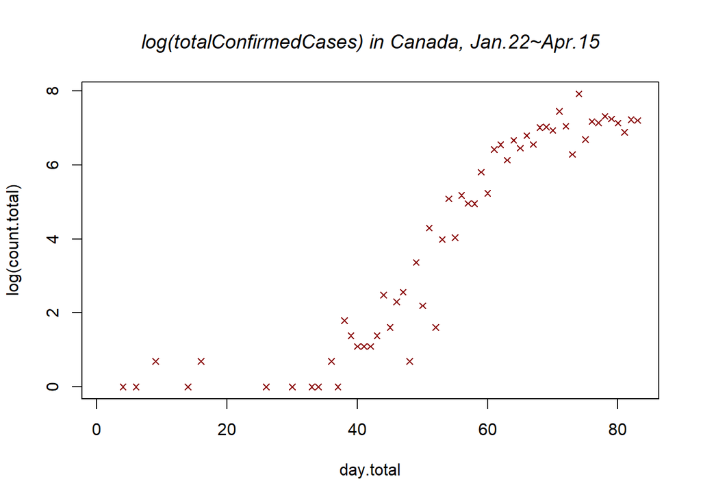

```r
count.total<-diff(train$ConfirmedCase)
day.total<-1:length(count.total)
plot(log(count.total)~day.total，pch=4,col="darkred",cex=.8)
title("log(totalConfirmedCases) in Canada, Jan.22~Apr.15",font.main=3)
```

From this plot, it can be seen that in the first twenty days of the data, the number of cases changed very slowly, this could be a concern in the modelling in terms of including or excluding this periods. If the first 20 days are included, the model can rarely be improved for future prediction since those data points are nearly 0 and barely change; however if not the sample size is too small.

*Plot `British Columbia` data*

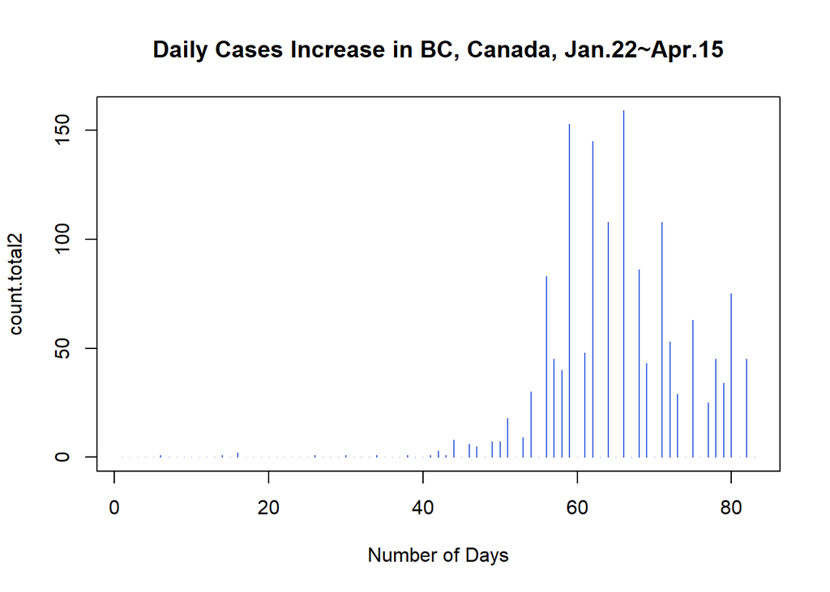

```r
train1<-read.csv('train.csv')
train1<-train1[which(train1$Country_Region=='Canada'),]
train1$province=droplevels(train1$Province_State)

count.total2<-diff(train1[which(train1['province']=='British Columbia'),]$ConfirmedCases)
day.total<-1:length(count.total2)
plot(count.total2, type = 'h',main="Daily Cases Increase in BC, Canada, Jan.22~Apr.15",
  xlab="Number of Days", col=c("royalblue"))
```

```r
# plot(log(count.total+1)~day.total)    # use `+1` to avoid log(0)
```

This plot shows that in day 40-80, there are several aperiodic cycles, the daily increase is 0, which indicates the data was not updated daily, so this could cause some trouble in the modelling of this data.

And we also plot the data of different province, several provinces showed the same problem of updating data not daily. Another finding is that, different province shows different cases increasing patterns. This should also be beard in mind in the evaluation of the models, since we take the data of the whole country as ONE.

## 1.General Linear Model

### 1.1 Data Processing

In this analysis, we mainly focused on the `ConfirmedCases` modelling and prediction. The data was splited into two subsets. The first set of 75 data records were used to fit some models and the second subset is used to test the models.

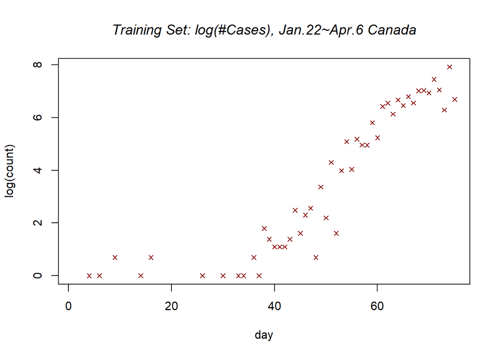

```r
count.total<-diff(train$ConfirmedCase)
day<-1:length(count.total)
count<-count.total[1:75]
count.test<-count.total[76:83]
day<-day[1:75]
day.test<-day[76:83]
plot(log(count)~day，pch=4,col="darkred",cex=.8)
title("Training Set: log(#Cases), Jan.22~Apr.6 Canada",font.main=3)
```

### 1.2 Fit the GLM model

```r
covid.glm<-glm(count~day,family=poisson(link='log'))
summary(covid.glm)
```

```
##
## Call:
## glm(formula = count ~ day, family = poisson(link = "log"))
##
## Deviance Residuals:
##     Min       1Q   Median       3Q      Max
## -32.228   -4.239   -1.670   -0.317   20.539
##
## Coefficients:
##              Estimate Std. Error z value Pr(>|z|)
## (Intercept) -2.512352   0.072343  -34.73   <2e-16 ***
## day          0.135475   0.001056  128.29   <2e-16 ***
## ---
## Signif. codes:  0 '***' 0.001 '**' 0.01 '*' 0.05 '.' 0.1 ' ' 1
##
## (Dispersion parameter for poisson family taken to be 1)
##
##     Null deviance: 48161.5  on 74  degrees of freedom
## Residual deviance:  4529.7  on 73  degrees of freedom
## AIC: 4798.1
##
## Number of Fisher Scoring iterations: 5
```

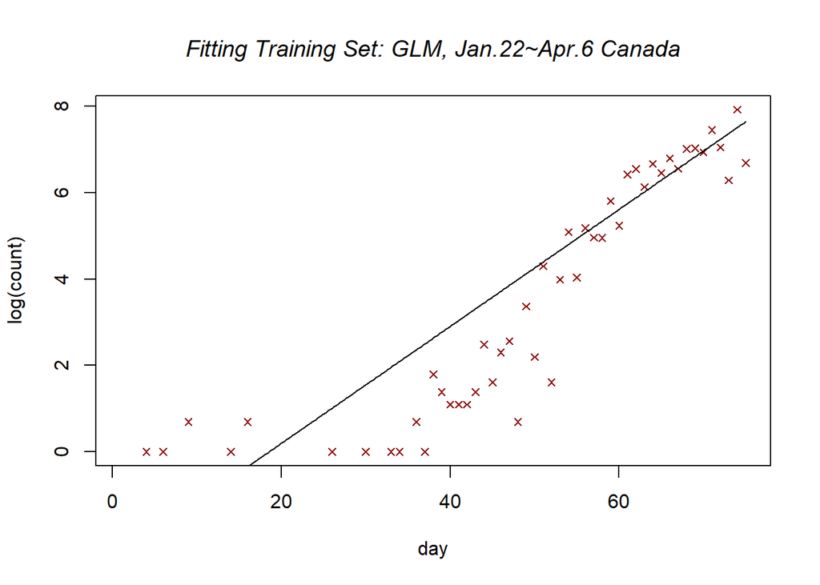

```r
suppressMessages(library(MPV))
plot(day,log(count),pch=4,col="darkred",cex=.8)
quadline(covid.glm)
title("Fitting Training Set: GLM, Jan.22~Apr.6 Canada",font.main=3)
```

### 1.3 Run Diagnostic check

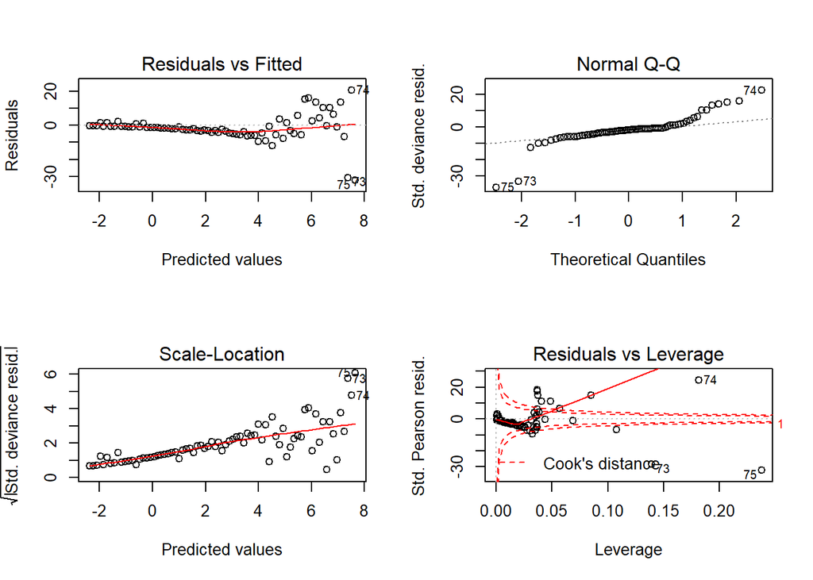

```r
par(mfrow=c(2,2))
plot(covid.glm)
```

There are some concerns from this plot, the major one is that there are some outliers in the data strongly influenced the model from the `Cook's distance` plot, and the reponse data is not normally distributed from the `QQ` plot. In the `Scale-Location` plot, there is an upward trend which is concerning. Generally the lower and upper bounds of datasets made the model inappropriate.

### 1.4 Sub-conclusion 1 of GLM model:

Overall, this model is **NOT** an appropriate model mainly because the the reponse of the data after `log()` is not linear(the total number of cases in Canada is not strictly following anything log-like), so it is hard to use a linear model to fit the data. So nonlinear model could be a possible solution.

## 2. Generalized Additive Model

### 2.1 Fit the model

```r
suppressMessages(library(mgcv))
covid.gam<-gam(count~s(day),family=poisson(link='log'),method="REML")
summary(covid.gam)
```

```
##
## Family: poisson
## Link function: log
##
## Formula:
## count ~ s(day)
##
## Parametric coefficients:
##             Estimate Std. Error z value Pr(>|z|)
## (Intercept)   1.8631     0.1361   13.69   <2e-16 ***
## ---
## Signif. codes:  0 '***' 0.001 '**' 0.01 '*' 0.05 '.' 0.1 ' ' 1
##
## Approximate significance of smooth terms:
##          edf Ref.df Chi.sq p-value
## s(day) 6.375  7.106   9308  <2e-16 ***
## ---
## Signif. codes:  0 '***' 0.001 '**' 0.01 '*' 0.05 '.' 0.1 ' ' 1
##
## R-sq.(adj) =   0.77   Deviance explained = 93.9%
## -REML = 1622.9  Scale est. = 1         n = 75
```

Obtain plot of the estimate of the spline function, together with its confidence band.

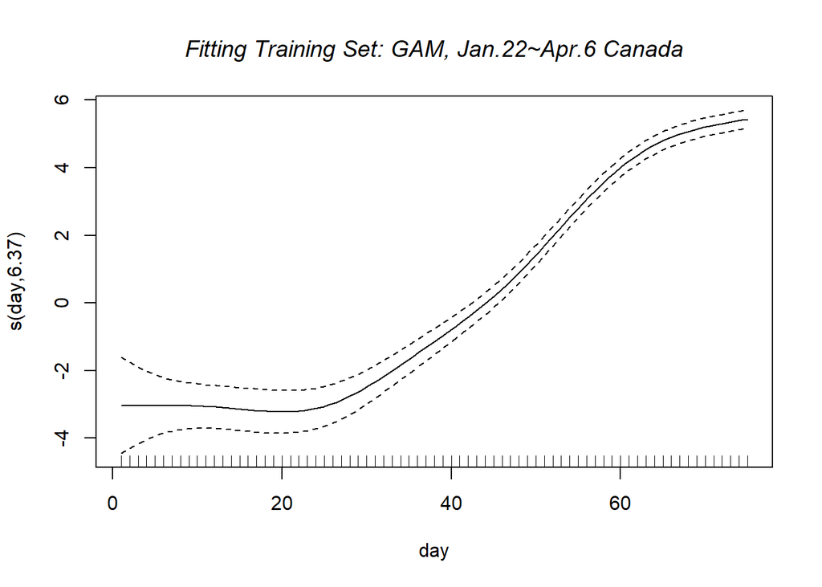

```r
plot(covid.gam)
title("Fitting Training Set: GAM, Jan.22~Apr.6 Canada",font.main=3)
```

Check the residual deviance

```r
print(paste("Null deviance: ",covid.gam$null.deviance))
```

```
## [1] "Null deviance:  48161.5287756111"
```

```r
print(paste("GLM deviance: ",covid.glm$deviance))
```

```
## [1] "GLM deviance:  4529.65672686472"
```

```r
print(paste("GAM deviance: ",covid.gam$deviance))
```

```
## [1] "GAM deviance:  2941.84805585687"
```

Compare with the `GLM` model in terms of residual deviance, this model improved largely. It would be a better model in this sense.

### 2.2 Prediction

Predict the test set(total number of cases) and evaluate the model:

```r
pre.gam=predict.gam(covid.gam,newdata=data.frame(day=seq(76,83)),type="response",se.fit = T)
pre.gam
```

```
## $fit
##        1        2        3        4        5        6        7        8
## 1542.389 1609.514 1679.560 1752.654 1828.930 1908.525 1991.584 2078.257
##
## $se.fit
##         1         2         3         4         5         6         7         8
##  35.34194  45.05463  55.82462  67.61910  80.44881  94.34736 109.36205 125.54959
```

```r
(pre.gam$fit-count.test)/pre.gam$se.fit
```

```
##        1        2        3        4        5        6        7        8
## 6.603746 7.557801 2.983628 5.141362 7.109237 9.809757 5.583139 5.760729
```

### 2.3 GAM Sub-conclusion 2:

First conclusion: based on the difference of the fitted value and true value, most of the differnces are around 6~7 standard errors, which are really big. So the `GAM` model is **NOT** a good model in this sense.

*Residual plot*

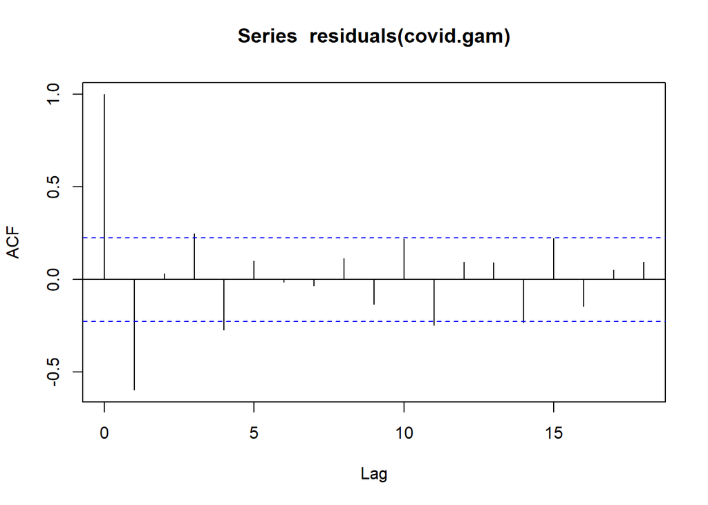

```r
acf(residuals(covid.gam))
```

Second conclusion: based on this residual autocorrelation check, the model seems autocorrelated. So, `ARIMA` model could be another possible solution. Let’s have a try:

## 3. ARIMA

### 3.1 Fit the model

Determine if the `daily case counts` are autocorrelated, and if so, fit an appropriate ARMA model to them.

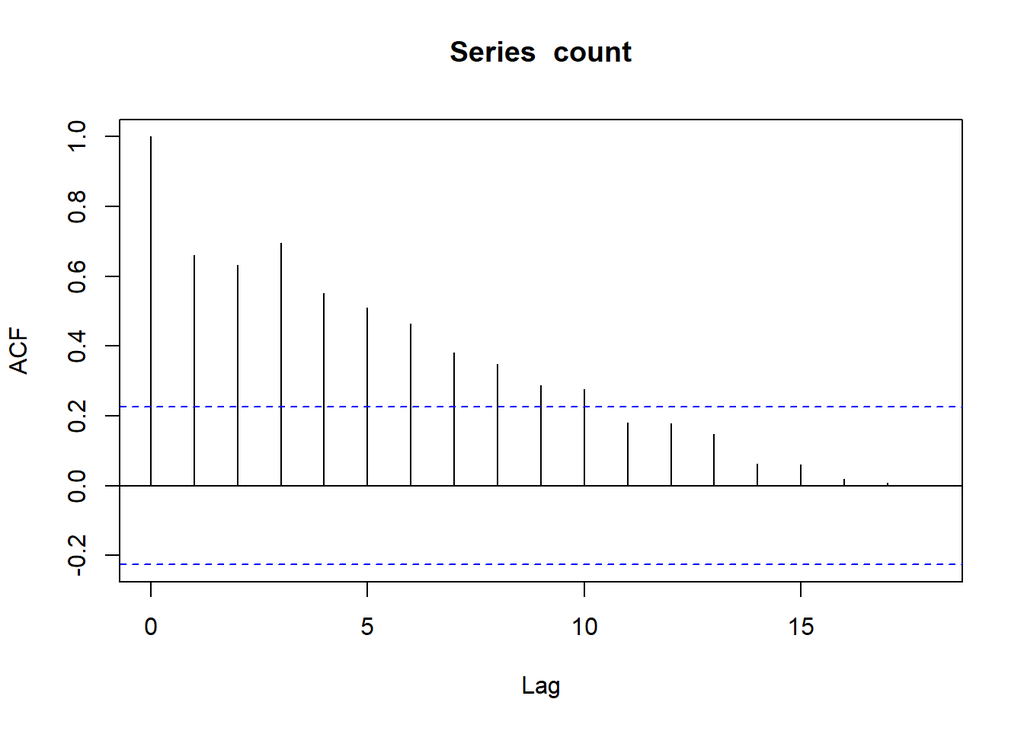

```r
acf(count)
```

From the above plot, it can be seen that the data is autocorrelated in some way. So we fitted a arima model using `auto.arima()`.

```r
suppressMessages(library(forecast))
covid.arima <- auto.arima(count)
covid.arima
```

```
## Series: count
## ARIMA(0,1,2) with drift
##
## Coefficients:
##           ma1     ma2    drift
##       -1.3574  0.7537  20.7957
## s.e.   0.0990  0.0708   9.1782
##
## sigma^2 estimated as 41698:  log likelihood=-498.38
## AIC=1004.76   AICc=1005.34   BIC=1013.98
```

### 3.2 Prediction:

Predict the next 8 days number of cases.

```r
fc<-forecast(count,model=covid.arima,h=8)
```

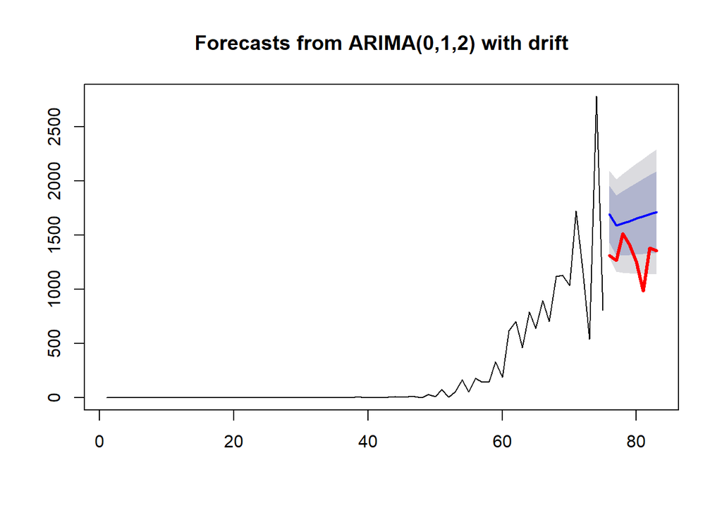

```r
plot(fc)
lines ((length(count)+1):(length(count)+length(count.test)), count.test, col="red", lwd=3)
```

Calculate the standard error of the `point forecast`.

```r
fsd <- (fc$upper[,1] - fc$lower[,1]) / (2 * qnorm(.5 + fc$level[1] / 200))
fsd
```

```
## Time Series:
## Start = 76
## End = 83
## Frequency = 1
## [1] 204.2003 216.8505 231.4554 245.1919 258.1986 270.5808 282.4207 293.7837
```

Then, compare the predicted values with the actual count by subtracting the actual values from the predictions and dividing by the estimated standard errors.

```r
(fc$mean -  count.test)/fsd
```

```
## Time Series:
## Start = 76
## End = 83
## Frequency = 1
## [1] 1.8780361 1.4709041 0.4137383 0.9158445 1.5234525 2.5432290 1.1009981
## [8] 1.2176994
```

### 3.3 Conclusions

Based on this calculation, most of differences between the fitted value and the actual daily case count is smaller than 2 standard errors. So, we accepted the null hypothesis the predicted and the acutal value are the same, and the model is a **PROPER** model.

## 4. Comments on models

### 4.1 Comparison of models

```r
print(paste("ARIMA AIC: ",AIC(covid.arima)))
```

```
## [1] "ARIMA AIC:  1004.76021428945"
```

```r
print(paste("GLM AIC: ",AIC(covid.glm)))
```

```
## [1] "GLM AIC:  4798.13042691383"
```

```r
print(paste("GAM AIC: ",AIC(covid.gam)))
```

```
## [1] "GAM AIC:  3221.47874670898"
```

# FINALL CONCLUSION:

In terms of AIC, clearly `ARIMA` model wins. The fitted ARIMA(0,1,2) model is :

Ŷ<sub>t</sub> = 20.7957 + Y<sub>t-1</sub> - 1.3574e<sub>t-1</sub> + 0.7537e<sub>t-2</sub> ,

So given number of increase/cases, previous two error terms we can generally predict the following number within 2*sigma.

In this project, since the data is a time series model, so the `ARIMA` model shows its advantages. For `GLM` and `GAM` model, it could be possible to fit the data at large, but the prediction of the next 5 or 10 days could be dangerous, since these models are not suitable for extrapolation beyond the data range.

From the first part of this report, it showed that the data is not updated daily or the daily increase stays at 0 at the first phase of the transmission. So this could bring some extra noise to the data.

One thing can be improved for these models is that: since we use aggregated values from all the province, the variance of the data could be reduced if we construct different models for different provinces and then aggregate the predicted value.